## CS441: Applied ML - HW 5

# Part 1: Applications of AI

Nothing to code for this part.

# Part 2: Fine-Tune for Pets Image Classification

Include all the code for Part 2 in this section

## 2.1 Prepare Data

```python
import torch
import torch.nn as nn
import torch.optim.lr_scheduler as lrs
from torch.utils.data import DataLoader
import torchvision
from torchvision import datasets
from torchvision import transforms
import matplotlib.pyplot as plt
from tqdm import tqdm

import os
from pathlib import Path
import numpy as np
```

```python
datadir = "."
save_dir = "."  # change to your directory
```

```python
def load_pet_dataset(train_transform = None, test_transform = None):
    OxfordIIITPet = datasets.OxfordIIITPet
    if os.path.isdir(datadir+ "oxford-iiit-pet"):
      do_download = False
    else:
      do_download = True
    training_set = OxfordIIITPet(root = datadir,
                             split = 'trainval',
                             transform = train_transform,
                             download = do_download)

    test_set = OxfordIIITPet(root = datadir,
                           split = 'test',
                           transform = test_transform,
                           download = do_download)
    return training_set, test_set
```

```
Label: Persian
```

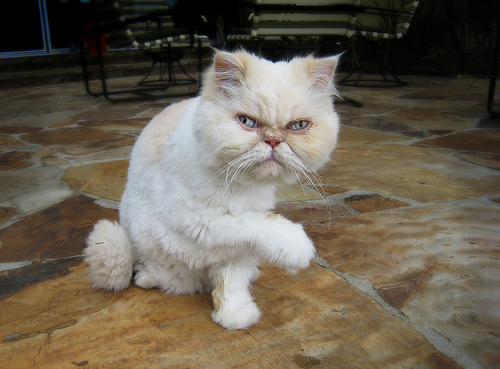

```python
train_set, test_set = load_pet_dataset()

# Display a sample in OxfordIIIPet dataset
sample_idx = 3000 # Choose an image index that you want to display
print("Label:", train_set.classes[train_set[sample_idx][1]])
train_set[sample_idx][0]
```

## 2.2 Data Preprocess

```python
from torchvision import transforms
from torch.utils.data import DataLoader
```

```python
# Feel free to add augmentation choices

# Apply data augmentation
train_transform = transforms.Compose([
            transforms.Resize(224),
            transforms.CenterCrop(224),
            transforms.ToTensor(),
            transforms.Normalize(mean=[0.485, 0.456, 0.406],
                                 std= [0.229, 0.224, 0.225]),
        ])

test_transform = transforms.Compose([
            transforms.Resize(224),  # resize to 224x224 because that's the size of ImageNet images
            transforms.CenterCrop(224),
            transforms.ToTensor(),
            transforms.Normalize(mean=[0.485, 0.456, 0.406],
                                 std= [0.229, 0.224, 0.225]),
        ])
```

```python
# Feel free to change
train_set, test_set = load_pet_dataset(train_transform, test_transform)
train_loader = DataLoader(dataset=train_set,
                          batch_size=64,
                          shuffle=True,
                          num_workers=2)

test_loader = DataLoader(dataset=test_set,
                          batch_size=64,
                          shuffle=False,
                          num_workers=2)
```

## 2.3 Helper Functions

```python
# Display the number of parameters and model structure
def display_model(model):
  # Check number of parameters
  summary_dict = {}
  num_params = 0
  summary_str = ['='*80]

  for module_name, module in model.named_children():
      summary_count = 0
      for name, param in module.named_parameters():
          if(param.requires_grad):
              summary_count += param.numel()
              num_params += param.numel()
      summary_dict[module_name] = [summary_count]
      summary_str+= [f'- {module_name: <40} : {str(summary_count):^34s}']

  summary_dict['total'] = [num_params]

  # print summary string
  summary_str += ['='*80]
  summary_str += ['--' +  f'{"Total":<40} : {str(num_params) + " params":^34s}' +'--']
  print('\n'.join(summary_str))

  # print model structure
  print(model)
```

```python
# Plot loss or accuracy
def plot_losses(train, val, test_frequency, num_epochs):
    plt.plot(train, label="train")
    indices = [i for i in range(num_epochs) if ((i+1)%test_frequency == 0 or i ==0 or i == 1)]
    plt.plot(indices, val, label="val")
    plt.title("Loss Plot")
    plt.ylabel("Loss")
    plt.xlabel("Epoch")
    plt.legend()
    plt.show()

def plot_accuracy(train, val, test_frequency, num_epochs):
    indices = [i for i in range(num_epochs) if ((i+1)%test_frequency == 0 or i ==0 or i == 1)]
    plt.plot(indices, train, label="train")
    plt.plot(indices, val, label="val")
    plt.title("Accuracy Plot")
    plt.ylabel("Accuracy")
    plt.xlabel("Epoch")
    plt.legend()
    plt.show()

def save_checkpoint(save_dir, model, save_name = 'best_model.pth'):
    save_path = os.path.join(save_dir, save_name)
    torch.save(model.state_dict(), save_path)

def load_model(model, save_dir, save_name = 'best_model.pth'):
    save_path = os.path.join(save_dir, save_name)
    model.load_state_dict(torch.load(save_path))
    return model
```

## 2.4 YOUR TASK: Fine-Tune Pre-trained Network on Pets

Read and understand the code and then uncomment it. Then, set up your learning rate, learning scheduler, and train/evaluate. Adjust as necessary to reach target performance.

```python
# set device, using GPU 'cuda' will be faster
device = 'cuda'
```

```python
def train(train_loader, model, criterion, optimizer):
    """
    Train network
    :param train_loader: training dataloader
    :param model: model to be trained
    :param criterion: criterion used to calculate loss (should be CrossEntropyLoss from torch.nn)
    :param optimizer: optimizer for model's params (Adams or SGD)
    :return: mean training loss
    """
    model.train()
    loss_ = 0.0
    losses = []

    # TO DO: read this documentation and then uncomment the line below; https://pypi.org/project/tqdm/
    it_train = tqdm(enumerate(train_loader), total=len(train_loader), desc="Training ...", position = 0) # progress bar
    for i, (images, labels) in it_train:

        # TO DO: read/understand these lines and then uncomment the code below

        images, labels = images.to(device), labels.to(device)

        # zero the gradient
        optimizer.zero_grad()

        # predict labels
        prediction = model(images)

        # compute loss
        loss = criterion(prediction, labels)

        # set text to display
        it_train.set_description(f'loss: {loss:.3f}')

        # compute gradients
        loss.backward()

        # update weights
        optimizer.step()

        # keep track of losses
        losses.append(loss)

    return torch.stack(losses).mean().item()

def test(test_loader, model, criterion):
    """
    Test network.
    :param test_loader: testing dataloader
    :param model: model to be tested
    :param criterion: criterion used to calculate loss (should be CrossEntropyLoss from torch.nn)
    :return: mean_accuracy: mean accuracy of predicted labels
             test_loss: mean test loss during testing
    """
    model.eval()
    losses = []
    correct = 0
    total = 0

    # TO DO: read this documentation and then uncomment the line below; https://pypi.org/project/tqdm/
    it_test = tqdm(enumerate(test_loader), total=len(test_loader), desc="Validating ...", position = 0)
    for i, (images, labels) in it_test:

      # TO DO: read/understand and then uncomment these lines

      images, labels = images.to(device), labels.to(device)
      with torch.no_grad():  # https://pytorch.org/docs/stable/generated/torch.no_grad.html
       output = model(images) # do not compute gradient when performing prediction
      preds = torch.argmax(output, dim=-1)
      loss = criterion(output, labels)
      losses.append(loss.item())
      correct += (preds == labels).sum().item()
      total += len(labels)

    mean_accuracy = correct / total
    test_loss = np.mean(losses)
    print('Mean Accuracy: {0:.4f}'.format(mean_accuracy))
    print('Avg loss: {}'.format(test_loss))

    return mean_accuracy, test_loss
```

```python
# loads a pre-trained ResNet-34 model
model = torch.hub.load('pytorch/vision:v0.10.0', 'resnet34', pretrained=True)
num_target_classes = 37

# TO DO: replace the last layer (classification head) with a new linear layer for Pets classification here
in_features = model.fc.in_features
model.fc = torch.nn.Linear(in_features, num_target_classes)

model = model.to(device)
display_model(model) # displays the model structure and parameter count
```

```
Using cache found in /home/janghl/.cache/torch/hub/pytorch_vision_v0.10.0
```

```
================================================================================
- conv1                                    :                9408
- bn1                                      :                128
- relu                                     :                 0
- maxpool                                  :                 0
- layer1                                   :               221952
- layer2                                   :              1116416
- layer3                                   :              6822400
- layer4                                   :              13114368
- avgpool                                  :                 0
- fc                                       :               18981
================================================================================
--Total                                    :          21303653 params          --
ResNet(
  (conv1): Conv2d(3, 64, kernel_size=(7, 7), stride=(2, 2), padding=(3, 3), bias=False)
  (bn1): BatchNorm2d(64, eps=1e-05, momentum=0.1, affine=True, track_running_stats=True)
  (relu): ReLU(inplace=True)
  (maxpool): MaxPool2d(kernel_size=3, stride=2, padding=1, dilation=1, ceil_mode=False)
  (layer1): Sequential(
    (0): BasicBlock(
      (conv1): Conv2d(64, 64, kernel_size=(3, 3), stride=(1, 1), padding=(1, 1), bias=False)
      (bn1): BatchNorm2d(64, eps=1e-05, momentum=0.1, affine=True, track_running_stats=True)
      (relu): ReLU(inplace=True)
      (conv2): Conv2d(64, 64, kernel_size=(3, 3), stride=(1, 1), padding=(1, 1), bias=False)
      (bn2): BatchNorm2d(64, eps=1e-05, momentum=0.1, affine=True, track_running_stats=True)
    )
    (1): BasicBlock(
      (conv1): Conv2d(64, 64, kernel_size=(3, 3), stride=(1, 1), padding=(1, 1), bias=False)
      (bn1): BatchNorm2d(64, eps=1e-05, momentum=0.1, affine=True, track_running_stats=True)
      (relu): ReLU(inplace=True)
      (conv2): Conv2d(64, 64, kernel_size=(3, 3), stride=(1, 1), padding=(1, 1), bias=False)
      (bn2): BatchNorm2d(64, eps=1e-05, momentum=0.1, affine=True, track_running_stats=True)
    )
    (2): BasicBlock(
      (conv1): Conv2d(64, 64, kernel_size=(3, 3), stride=(1, 1), padding=(1, 1), bias=False)
      (bn1): BatchNorm2d(64, eps=1e-05, momentum=0.1, affine=True, track_running_stats=True)
      (relu): ReLU(inplace=True)
      (conv2): Conv2d(64, 64, kernel_size=(3, 3), stride=(1, 1), padding=(1, 1), bias=False)
      (bn2): BatchNorm2d(64, eps=1e-05, momentum=0.1, affine=True, track_running_stats=True)
    )
```

[output cut: 98 more lines]

```
      (relu): ReLU(inplace=True)
      (conv2): Conv2d(512, 512, kernel_size=(3, 3), stride=(1, 1), padding=(1, 1), bias=False)
      (bn2): BatchNorm2d(512, eps=1e-05, momentum=0.1, affine=True, track_running_stats=True)
    )
    (2): BasicBlock(
      (conv1): Conv2d(512, 512, kernel_size=(3, 3), stride=(1, 1), padding=(1, 1), bias=False)
      (bn1): BatchNorm2d(512, eps=1e-05, momentum=0.1, affine=True, track_running_stats=True)
      (relu): ReLU(inplace=True)
      (conv2): Conv2d(512, 512, kernel_size=(3, 3), stride=(1, 1), padding=(1, 1), bias=False)
      (bn2): BatchNorm2d(512, eps=1e-05, momentum=0.1, affine=True, track_running_stats=True)
    )
  )
  (avgpool): AdaptiveAvgPool2d(output_size=(1, 1))
  (fc): Linear(in_features=512, out_features=37, bias=True)
)
```

```python
# Training Setting. Feel free to change.
num_epochs = 10
test_interval = 1

# TO DO: set initial learning rate
learn_rate = 1e-4
optimizer = torch.optim.Adam(model.parameters(), lr=learn_rate)

# TO DO: define your learning rate scheduler, e.g. StepLR
# https://pytorch.org/docs/stable/optim.html#module-torch.optim.lr_scheduler
lr_scheduler =  torch.optim.lr_scheduler.StepLR(optimizer, step_size=1, gamma=0.9)

criterion = torch.nn.CrossEntropyLoss()

train_losses = []
train_accuracy_list = []
test_losses = []
test_accuracy_list = []


# Iterate over the DataLoader for training data
for epoch in tqdm(range(num_epochs), total=num_epochs, desc="Training ...", position=1):
    # Train the network for one epoch
    train_loss = train(train_loader, model, criterion, optimizer)

    # TO DO: uncomment the line below. It should be called each epoch to apply the lr_scheduler
    lr_scheduler.step()

    train_losses.append(train_loss)
    print(f'Loss for Training on epoch {str(epoch)} is {str(train_loss)} \n')

    # Get the train accuracy and test loss/accuracy
    if(epoch%test_interval==0 or epoch==1 or epoch==num_epochs-1):
        print('Evaluating Network')

        train_accuracy, _ = test(train_loader, model, criterion) # Get training accuracy
        train_accuracy_list.append(train_accuracy)

        print(f'Training accuracy on epoch {str(epoch)} is {str(train_accuracy)} \n')

        test_accuracy, test_loss = test(test_loader, model, criterion) # Get testing accuracy and error
        test_losses.append(test_loss)
        test_accuracy_list.append(test_accuracy)
        print(f'Test (val) accuracy on epoch {str(epoch)} is {str(test_accuracy)} \n')

        # Checkpoints are used to save the model with best validation accuracy
        if test_accuracy >= max(test_accuracy_list):
          print("Saving Model")
          save_checkpoint(save_dir, model, save_name = 'best_model.pth') # Save model with best performance
```

```
Loss for Training on epoch 0 is 1.3497225046157837

Evaluating Network
```

```
Mean Accuracy: 0.9747
Avg loss: 0.24443417993085137
Training accuracy on epoch 0 is 0.9747282608695652
```

```
Mean Accuracy: 0.8913
Avg loss: 0.505778176003489
Test (val) accuracy on epoch 0 is 0.8912510220768601

Saving Model
```

```
Loss for Training on epoch 1 is 0.19841448962688446

Evaluating Network
```

```
Mean Accuracy: 0.9962
Avg loss: 0.05935830410955281
Training accuracy on epoch 1 is 0.996195652173913
```

```
Mean Accuracy: 0.8972
Avg loss: 0.387282551491055
Test (val) accuracy on epoch 1 is 0.8972472063232488

Saving Model
```

```
Loss for Training on epoch 2 is 0.057415686547756195

Evaluating Network
```

```
Mean Accuracy: 1.0000
Avg loss: 0.01590884475294372
Training accuracy on epoch 2 is 1.0
```

```
Mean Accuracy: 0.9122
Avg loss: 0.31880737738362674
Test (val) accuracy on epoch 2 is 0.9122376669392205

Saving Model
```

```
Loss for Training on epoch 3 is 0.02456776797771454

Evaluating Network
```

```
Mean Accuracy: 1.0000
Avg loss: 0.00957316209176748
Training accuracy on epoch 3 is 1.0
```

```
Mean Accuracy: 0.9106
Avg loss: 0.31288707840802343
Test (val) accuracy on epoch 3 is 0.9106023439629327
```

```
Loss for Training on epoch 4 is 0.016316721215844154

Evaluating Network
```

```
Mean Accuracy: 1.0000
Avg loss: 0.0059770000456222175
Training accuracy on epoch 4 is 1.0
```

```
Mean Accuracy: 0.9207
Avg loss: 0.2894534972849591
Test (val) accuracy on epoch 4 is 0.9206868356500408

Saving Model
```

```
Loss for Training on epoch 5 is 0.010935946367681026

Evaluating Network
```

```
Mean Accuracy: 1.0000
Avg loss: 0.004317048186404181
Training accuracy on epoch 5 is 1.0
```

```
Mean Accuracy: 0.9210
Avg loss: 0.2850372875109315
Test (val) accuracy on epoch 5 is 0.9209593894794222

Saving Model
```

```
Loss for Training on epoch 6 is 0.00921674631536007

Evaluating Network
```

```
Mean Accuracy: 1.0000
Avg loss: 0.0036559286166046715
Training accuracy on epoch 6 is 1.0
```

```
Mean Accuracy: 0.9204
Avg loss: 0.2835886925780054
Test (val) accuracy on epoch 6 is 0.9204142818206595
```

```
Loss for Training on epoch 7 is 0.007689479738473892

Evaluating Network
```

```
Mean Accuracy: 1.0000
Avg loss: 0.0029499575511777194
Training accuracy on epoch 7 is 1.0
```

```
Mean Accuracy: 0.9199
Avg loss: 0.28181350989074544
Test (val) accuracy on epoch 7 is 0.919869174161897
```

```
Loss for Training on epoch 8 is 0.00715823145583272

Evaluating Network
```

```
Mean Accuracy: 1.0000
Avg loss: 0.0027045900692585214
Training accuracy on epoch 8 is 1.0
```

```
Mean Accuracy: 0.9185
Avg loss: 0.28851110982740746
Test (val) accuracy on epoch 8 is 0.9185064050149905
```

```
Loss for Training on epoch 9 is 0.006114728283137083

Evaluating Network
```

```
Mean Accuracy: 1.0000
Avg loss: 0.0022216173077548116
Training accuracy on epoch 9 is 1.0
```

```
Mean Accuracy: 0.9185
Avg loss: 0.282880000994894
Test (val) accuracy on epoch 9 is 0.9185064050149905
```

## 2.5 Plotting of losses and accuracy

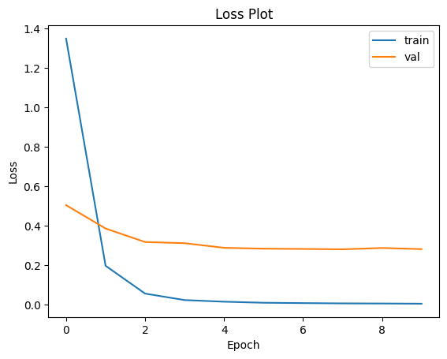

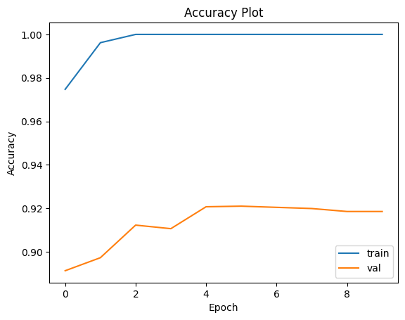

```python
plot_losses(train_losses, test_losses, test_interval, num_epochs)
plot_accuracy(train_accuracy_list, test_accuracy_list, test_interval, num_epochs)
```

## 2.6 Evaluating trained model

```python
# TO DO: initialize your trained model as you did before so that you can load the parameters into it

model = torch.hub.load('pytorch/vision:v0.10.0', 'resnet34', pretrained=True)
# replace last layer
in_features = model.fc.in_features
model.fc = torch.nn.Linear(in_features, num_target_classes)

model = model.to(device)
load_model(model, save_dir) # Load the trained weight

test_accuracy, test_loss= test(test_loader, model, criterion)
print(f"Validation accuracy is {str(test_accuracy)} \n")
```

```
Using cache found in /home/janghl/.cache/torch/hub/pytorch_vision_v0.10.0
```

```
Mean Accuracy: 0.9210
Avg loss: 0.2850372875109315
Validation accuracy is 0.9209593894794222
```

# Part 3: CLIP: Contrastive Language-Image Pretraining

Include all the code for Part 3 in this section

### 3.1 Prepare data

[Here](https://drive.google.com/file/d/1zJ1KfymSfsbmD6QS-F0eUC8T1PkqW0_j/view?usp=sharing) is the json file you need for labels of flowers 102

```python
import json
import os
import os.path as osp
import numpy as np
import torch
from torchvision.datasets import Flowers102
%matplotlib inline
from matplotlib import pyplot as plt
```

```python
datadir = "."
```

```python
def load_flower_data(img_transform=None):
    if os.path.isdir(datadir+ "flowers-102"):
      do_download = False
    else:
      do_download = True
    train_set = Flowers102(root=datadir, split='train', transform=img_transform, download=do_download)
    test_set = Flowers102(root=datadir, split='val', transform=img_transform, download=do_download)
    classes = json.load(open(osp.join(datadir, "flowers102_classes.json")))

    return train_set, test_set, classes
```

```python
# READ ME!  This takes some time (a few minutes), so if you are using Colabs and want to use GPU for speed,
#           first set to use GPU: Edit->Notebook Settings->Hardware Accelerator=GPU, and restart instance

# Data structure details
#   flower_train[n][0] is the nth train image
#   flower_train[n][1] is the nth train label
#   flower_test[n][0] is the nth test image
#   flower_test[n][1] is the nth test label
#   flower_classes[k] is the name of the kth class
flower_train, flower_test, flower_classes = load_flower_data()
```

```python
len(flower_train), len(flower_test)  # output should be (1020, 1020)
```

```
(1020, 1020)
```

[output not shown]

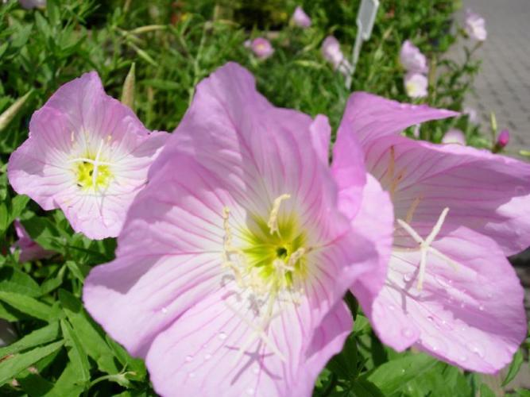

```python
# Display a sample in Flowers 102 dataset
sample_idx = 5 # Choose an image index that you want to display
print("Label:", flower_classes[flower_train[sample_idx][1]])
flower_train[sample_idx][0]
```

### 3.2 Prepare CLIP model

```python
!pip install git+https://github.com/openai/CLIP.git
```

```
  Cloning https://github.com/openai/CLIP.git to /tmp/pip-req-build-4_ff0q1l
  Running command git clone --filter=blob:none --quiet https://github.com/openai/CLIP.git /tmp/pip-req-build-4_ff0q1l
  Resolved https://github.com/openai/CLIP.git to commit a1d071733d7111c9c014f024669f959182114e33
  Preparing metadata (setup.py) ... done
```

```python
import clip
```

```python
# Sets device to "cuda" if a GPU is available
device = "cuda" if torch.cuda.is_available() else 'cpu'
print(device)
# If this takes a really long time, stop and then restart the download
clip_model, clip_preprocess = clip.load("ViT-B/32", device=device)
```

```
cuda
```

### 3.3 CLIP zero-shot prediction

[output not shown]

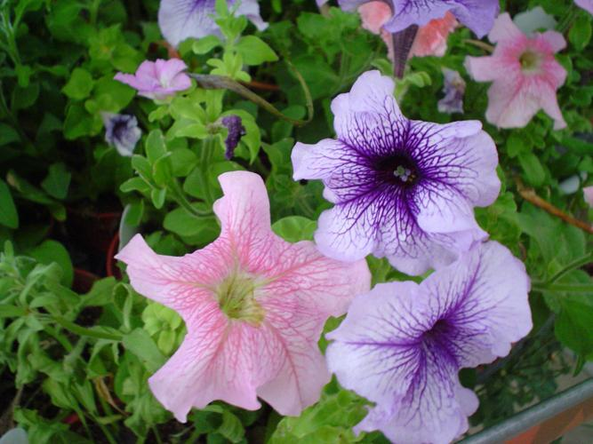

```python
"""The following is an example of using CLIP pre-trained model for zero-shot prediction task"""
# Prepare the inputs
n = 500  # image index to use
image, class_id = flower_train[n]
image_input = clip_preprocess(image).unsqueeze(0).to(device) # extract image and put in device memory
text_inputs = torch.cat([clip.tokenize(f"a photo of a {c}, a type of flower.") for c in flower_classes]).to(device) # put text to match to image in device memory

# Calculate features
with torch.no_grad():
    image_features = clip_model.encode_image(image_input) # compute image features with CLIP model
    text_features = clip_model.encode_text(text_inputs) # compute text features with CLIP model
image_features /= image_features.norm(dim=-1, keepdim=True) # unit-normalize image features
text_features /= text_features.norm(dim=-1, keepdim=True) # unit-normalize text features

# Pick the top 5 most similar labels for the image
similarity = (100.0 * image_features @ text_features.T) # score is cosine similarity times 100
p_class_given_image= similarity.softmax(dim=-1)  # P(y|x) is score through softmax
values, indices = p_class_given_image[0].topk(5) # gets the top 5 labels

# Print the probability of the top five labels
print("Ground truth:", flower_classes[class_id])
print("\nTop predictions:\n")
for value, index in zip(values, indices):
    print(f"{flower_classes[index]:>16s}: {100 * value.item():.2f}%")
image
```

### 3.4 YOUR TASK: Test CLIP zero-shot performance on Flowers 102

Use pre-trained text and image representations to classify images. For zero-shot recognition, text features are computed from the CLIP model for phrases such as “An image of [flower_name], a type of flower” for varying [flower_name] inserts. Then, image features are computed using the CLIP model for an image, and the cosine similarity between each text and image is computed. The label corresponding to the most similar text is assigned to the image. You'll get that working using a data loader, which enables faster batch processing; then, compute the accuracy over the test set. You should see top-1 accuracy in the 60-70% range.

For zero-shot, you do not use the training set at all. You should only have to compute the text vectors once and re-use them for all test images.

Basic steps:

1. Create the normalized CLIP text vectors for each class label.
2. For each batch:
   - Create normalized CLIP image vectors
   - Compute similarity between text and image vectors
   - Get index of most likely class label and check whether it matches the ground truth
   - Keep a count of number correct and number total
3. Return accuracy = # correct / # total

```python
from tqdm import tqdm
from torch.utils.data import DataLoader
```

```python
# Load flowers dataset again. This time, with clip_preprocess as transform (you don't have to call clip_preprocess again)
flower_train_trans, flower_test_trans, flower_classes = load_flower_data(img_transform=clip_preprocess)
```

```python
def clip_zero_shot(data_set, classes):
    # data_loader = DataLoader(data_set, batch_size=32, shuffle=False)  # dataloader lets you process in batch which is way faster (when using GPU)
    # TO DO: Needs code here
    correct = 0
    total = 0
    for batch in tqdm(data_set):
        image_input = batch[0].unsqueeze(0).to(device)
        text_inputs = torch.cat([clip.tokenize(f"a photo of a {c}, a type of flower.") for c in classes]).to(device) # put text to match to image in device memory
        with torch.no_grad():
            image_features = clip_model.encode_image(image_input)
            text_features = clip_model.encode_text(text_inputs)
        image_features /= image_features.norm(dim=-1, keepdim=True)
        text_features /= text_features.norm(dim=-1, keepdim=True)
        similarity = (100.0 * image_features @ text_features.T).softmax(dim=-1)
        values, indices = similarity[0].topk(5)
        # print(f"{indices[0]}, {batch[1]}")
        if batch[1] == indices[0]:
            correct += 1
        total += 1


    accuracy = correct / total

    return accuracy
```

```python
accuracy = clip_zero_shot(data_set=flower_test_trans, classes=flower_classes)
print(f"\nAccuracy = {100*accuracy:.3f}")
```

[output not shown]

### 3.5 YOUR TASK: Test CLIP linear probe performance on Flowers 102

We do not use text features for the linear probe method. Train on the train set, and evaluate on the test set and report your performance. You can get top-1 accuracy in the 90-95% range. If you’re getting in the 80’s, try both normalizing and not normalizing the features.

```python
from sklearn.linear_model import LogisticRegression
```

```python
"""
Returns image features and labels in numpy format.
The labels should just be integers representing class index, not text vectors.
"""
def get_features(data_set):
    # TO DO: Needs code here to extract features and labels
    all_features = []
    all_labels = []

    with torch.no_grad():
        for images, labels in tqdm(DataLoader(data_set, batch_size=100)):
            features = clip_model.encode_image(images.to(device))

            all_features.append(features)
            all_labels.append(labels)

    return torch.cat(all_features).cpu().numpy(), torch.cat(all_labels).cpu().numpy()
```

```python
# Calculate the image features
train_features, train_labels = get_features(flower_train_trans)
test_features, test_labels = get_features(flower_test_trans)

# TO DO: Needs code here
# Train logistic regression model with train_features, train_labels
classifier = LogisticRegression(random_state=0, C=0.316, max_iter=1000, verbose=1)
classifier.fit(train_features, train_labels)

# Evaluate accuracy on test_features, test_labels
predictions = classifier.predict(test_features)
accuracy = np.mean((test_labels == predictions).astype(float)) * 100.
print(f"Accuracy = {accuracy:.3f}")
```

```
 This problem is unconstrained.
```

[output not shown]

### 3.6 YOUR TASK: Evaluate a nearest-neighbor classifier on CLIP features

Extract features based on the pre-trained model (can be the same features as 3.5) and apply a nearest neighbor classifier. You can use your own implementation of nearest neighbor or a library like sklearn or FAISS for this. Try K={1, 3, 5, 7, 11, 21}. If using sklearn, you can also experiment with 'uniform' and 'distance' weighting. Report performance for best K on the test set. You can also experiment with using unnormalized or normalized features. You should see top-1 accuracy in the 80-90% range.

```python
# TO DO: code for KNN prediction and evaluation (may use sklearn.neighbors.NeighborsClassifier or FAISS or own implementation)
from sklearn.neighbors import KNeighborsClassifier

for k in [1, 3, 5, 7, 11, 21]:
    classifier = KNeighborsClassifier(n_neighbors=k)
    classifier.fit(train_features, train_labels)
    predictions = classifier.predict(test_features)
    accuracy = np.mean((test_labels == predictions).astype(float)) * 100.
    print(f"k={k}\nAccuracy = {accuracy:.3f}%")
```

```
k=1
Accuracy = 85.000%
k=3
Accuracy = 84.216%
k=5
Accuracy = 84.706%
k=7
Accuracy = 85.196%
k=11
Accuracy = 83.627%
k=21
Accuracy = 78.725%
```

## Part 4: Stretch Goals

Include any new code needed for Part 4 here.

## 4.a Compare word tokenizers

Train at least two 8K token word tokenizers (e.g. BPE, WordPiece, SentencePiece) on the WikiText-2, and compare their encodings. You can use existing libraries, such as those linked below to train and encode/decode. Report the encodings for “I am learning about word tokenizers. They are not very complicated, and they are a good way to convert natural text into tokens.” E.g. “I am the fastest planet” may end up being tokenized as [I, _am, _the, _fast, est, _plan, et]. Also, report the tokenizations of an additional sentence of your choice that results in different encodings by the two models.

https://github.com/huggingface/tokenizers

```python
# Choose your model between Byte-Pair Encoding, WordPiece or Unigram and instantiate a tokenizer:

from tokenizers import Tokenizer
from tokenizers.models import BPE
from datasets import load_dataset

dataset = load_dataset(path="wikitext", name="wikitext-2-raw-v1")
tokenizer = Tokenizer(BPE())
# You can customize how pre-tokenization (e.g., splitting into words) is done:

from tokenizers.pre_tokenizers import Whitespace

tokenizer.pre_tokenizer = Whitespace()
# Then training your tokenizer on a set of files just takes two lines of codes:

from tokenizers.trainers import BpeTrainer

trainer = BpeTrainer(special_tokens=["[UNK]", "[CLS]", "[SEP]", "[PAD]", "[MASK]"])
tokenizer.train(files=[], trainer)
# Once your tokenizer is trained, encode any text with just one line:

output = tokenizer.encode("I am learning about word tokenizers. They are not very complicated, and they are a good way to convert natural text into tokens.")
print(output.tokens)
# ["Hello", ",", "y", "'", "all", "!", "How", "are", "you", "[UNK]","?"]
```

[output not shown]

## 4.b Implement your own network

For the Oxford Pets dataset, try to write the network by yourself. You can get ideas from existing works, but you cannot directly import them using packages, and the parameter number should be lower than 20M. Train your network from scratch. You would get points if your network can reach an accuracy of 35% (15 pts), and another 15 pts if it reaches 45%. You would want to pay more attention to data augmentation and other hyper-parameters during this part. Feel free to re-use any functions defined in Part 2.

```python
# example network definition that needs to be modified for custom network stretch goal
from torch import nn

class ResBlock(nn.Module):
    def __init__(self, in_channels, out_channels, downsample):
        super().__init__()
        if downsample:
            self.conv1 = nn.Conv2d(in_channels, out_channels, kernel_size=3, stride=2, padding=1)
            self.shortcut = nn.Sequential(
            nn.Conv2d(in_channels, out_channels, kernel_size=1, stride=2),
            nn.BatchNorm2d(out_channels)
            )
        else:
            self.conv1 = nn.Conv2d(in_channels, out_channels, kernel_size=3, stride=1, padding=1)
            self.shortcut = nn.Sequential()
            self.conv2 = nn.Conv2d(out_channels, out_channels, kernel_size=3, stride=1, padding=1)
            self.bn1 = nn.BatchNorm2d(out_channels)
            self.bn2 = nn.BatchNorm2d(out_channels)

    def forward(self, input):
        shortcut = self.shortcut(input)
        input = nn.ReLU()(self.bn1(self.conv1(input)))
        input = nn.ReLU()(self.bn2(self.conv2(input)))
        input = input + shortcut
        return nn.ReLU()(input)

class Network(nn.Module):
    def __init__(self, num_classes=37):
        super().__init__()
        resblock = ResBlock
        self.layer0 = nn.Sequential(
        nn.Conv2d(3, 64, kernel_size=7, stride=2, padding=3),
        nn.MaxPool2d(kernel_size=3, stride=2, padding=1),
        nn.BatchNorm2d(64),
        nn.ReLU()
        )
        self.layer1 = nn.Sequential(
        resblock(64, 64, downsample=False),
        resblock(64, 64, downsample=False)
        )
        self.layer2 = nn.Sequential(
        resblock(64, 128, downsample=True),
        resblock(128, 128, downsample=False)
        )
        self.layer3 = nn.Sequential(
        resblock(128, 256, downsample=True),
        resblock(256, 256, downsample=False)
        )
        self.layer4 = nn.Sequential(
        resblock(256, 512, downsample=True),
        resblock(512, 512, downsample=False)
        )
        self.gap = torch.nn.AdaptiveAvgPool2d(1)
        self.fc = torch.nn.Linear(512, num_classes)

    def forward(self, input):
        input = self.layer0(input)
        input = self.layer1(input)
        input = self.layer2(input)
        input = self.layer3(input)
        input = self.layer4(input)
        input = self.gap(input)
        input = torch.flatten(input, 1)
        input = self.fc(input)
        return input
```

```python
model = Network()

# Feel free to change
train_set, test_set = load_pet_dataset(train_transform, test_transform)
train_loader = DataLoader(dataset=train_set,
                          batch_size=64,
                          shuffle=True,
                          num_workers=2)

test_loader = DataLoader(dataset=test_set,
                          batch_size=64,
                          shuffle=False,
                          num_workers=2)

# TO DO: replace the last layer (classification head) with a new linear layer for Pets classification here
# in_features = model.fc.in_features
# model.fc = torch.nn.Linear(in_features, num_target_classes)
device = 'cuda'
model = model.to(device)
display_model(model) # displays the model structure and parameter count
```

```
================================================================================
- layer0                                   :                9600
- layer1                                   :               148224
- layer2                                   :               378112
- layer3                                   :              1509888
- layer4                                   :              6034432
- gap                                      :                 0
- fc                                       :               18981
================================================================================
--Total                                    :           8099237 params          --
Network(
  (layer0): Sequential(
    (0): Conv2d(3, 64, kernel_size=(7, 7), stride=(2, 2), padding=(3, 3))
    (1): MaxPool2d(kernel_size=3, stride=2, padding=1, dilation=1, ceil_mode=False)
    (2): BatchNorm2d(64, eps=1e-05, momentum=0.1, affine=True, track_running_stats=True)
    (3): ReLU()
  )
  (layer1): Sequential(
    (0): ResBlock(
      (conv1): Conv2d(64, 64, kernel_size=(3, 3), stride=(1, 1), padding=(1, 1))
      (shortcut): Sequential()
      (conv2): Conv2d(64, 64, kernel_size=(3, 3), stride=(1, 1), padding=(1, 1))
      (bn1): BatchNorm2d(64, eps=1e-05, momentum=0.1, affine=True, track_running_stats=True)
      (bn2): BatchNorm2d(64, eps=1e-05, momentum=0.1, affine=True, track_running_stats=True)
    )
    (1): ResBlock(
      (conv1): Conv2d(64, 64, kernel_size=(3, 3), stride=(1, 1), padding=(1, 1))
      (shortcut): Sequential()
      (conv2): Conv2d(64, 64, kernel_size=(3, 3), stride=(1, 1), padding=(1, 1))
      (bn1): BatchNorm2d(64, eps=1e-05, momentum=0.1, affine=True, track_running_stats=True)
      (bn2): BatchNorm2d(64, eps=1e-05, momentum=0.1, affine=True, track_running_stats=True)
    )
  )
  (layer2): Sequential(
    (0): ResBlock(
      (conv1): Conv2d(64, 128, kernel_size=(3, 3), stride=(2, 2), padding=(1, 1))
      (shortcut): Sequential(
        (0): Conv2d(64, 128, kernel_size=(1, 1), stride=(2, 2))
        (1): BatchNorm2d(128, eps=1e-05, momentum=0.1, affine=True, track_running_stats=True)
      )
```

[output cut: 29 more lines]

```
        (0): Conv2d(256, 512, kernel_size=(1, 1), stride=(2, 2))
        (1): BatchNorm2d(512, eps=1e-05, momentum=0.1, affine=True, track_running_stats=True)
      )
    )
    (1): ResBlock(
      (conv1): Conv2d(512, 512, kernel_size=(3, 3), stride=(1, 1), padding=(1, 1))
      (shortcut): Sequential()
      (conv2): Conv2d(512, 512, kernel_size=(3, 3), stride=(1, 1), padding=(1, 1))
      (bn1): BatchNorm2d(512, eps=1e-05, momentum=0.1, affine=True, track_running_stats=True)
      (bn2): BatchNorm2d(512, eps=1e-05, momentum=0.1, affine=True, track_running_stats=True)
    )
  )
  (gap): AdaptiveAvgPool2d(output_size=1)
  (fc): Linear(in_features=512, out_features=37, bias=True)
)
```

```python
# Training Setting. Feel free to change.
num_epochs = 10
test_interval = 1

# TO DO: set initial learning rate
learn_rate = 1e-3
optimizer = torch.optim.Adam(model.parameters(), lr=learn_rate)

# TO DO: define your learning rate scheduler, e.g. StepLR
# https://pytorch.org/docs/stable/optim.html#module-torch.optim.lr_scheduler
lr_scheduler =  torch.optim.lr_scheduler.StepLR(optimizer, step_size=1, gamma=0.9)

criterion = torch.nn.CrossEntropyLoss()

train_losses = []
train_accuracy_list = []
test_losses = []
test_accuracy_list = []


# Iterate over the DataLoader for training data
for epoch in tqdm(range(num_epochs), total=num_epochs, desc="Training ...", position=1):
    # Train the network for one epoch
    train_loss = train(train_loader, model, criterion, optimizer)

    # TO DO: uncomment the line below. It should be called each epoch to apply the lr_scheduler
    lr_scheduler.step()

    train_losses.append(train_loss)
    print(f'Loss for Training on epoch {str(epoch)} is {str(train_loss)} \n')

    # Get the train accuracy and test loss/accuracy
    if(epoch%test_interval==0 or epoch==1 or epoch==num_epochs-1):
        print('Evaluating Network')

        train_accuracy, _ = test(train_loader, model, criterion) # Get training accuracy
        train_accuracy_list.append(train_accuracy)

        print(f'Training accuracy on epoch {str(epoch)} is {str(train_accuracy)} \n')

        test_accuracy, test_loss = test(test_loader, model, criterion) # Get testing accuracy and error
        test_losses.append(test_loss)
        test_accuracy_list.append(test_accuracy)
        print(f'Test (val) accuracy on epoch Test (val) accuracy on epoch {str(epoch)} is {str(test_accuracy)} \n')

        # Checkpoints are used to save the model with best validation accuracy
        if test_accuracy >= max(test_accuracy_list):
          print("Saving Model")
          save_checkpoint(save_dir, model, save_name = 'own_best_model.pth') # Save model with best performance
```

[output not shown]

[output cut: 16 more lines]

[output not shown]

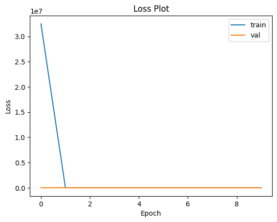

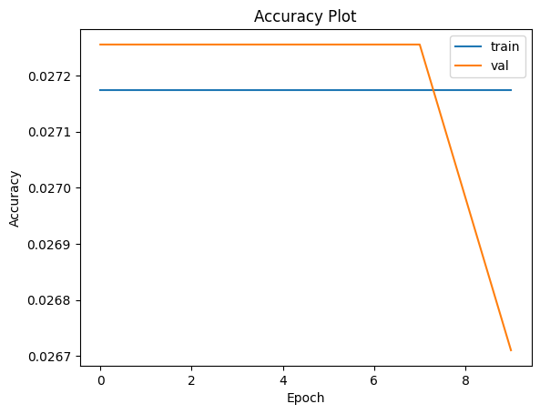

```python
plot_losses(train_losses, test_losses, test_interval, num_epochs)
plot_accuracy(train_accuracy_list, test_accuracy_list, test_interval, num_epochs)
```